# ml_hw1

Connected to ml_hw1 (Python 3.11.13)

## 1. Постановка задачи

**Бизнес-постановка.** В любой игре с риском игрок принимает решения, не зная точно, выиграет он или проиграет. В покере каждое действие (поставить, уравнять, сбросить карты) связано с вероятностью выигрыша и потенциальной прибылью или убытком. Главная бизнес-цель — **научиться оценивать, насколько разумно текущее действие**, чтобы уменьшать потери и повышать долгосрочный выигрыш. Проще говоря, мы хотим построить инструмент, который подсказывает: «Если в этой ситуации ты играешь так — насколько велик шанс, что это приведёт к победе?».

Такая система может использоваться:

- для анализа игровых стратегий (например, тренажёры покера или симуляторы ставок),
- для автоматизированных решений в задачах риска и неопределённости (бизнес-ставки, торги, оптимизация стратегий).

**ML-постановка.** Машинное обучение решает задачу **бинарной классификации**: нужно предсказать метку `win = 1` (победа) или `win = 0` (поражение) по набору признаков, описывающих состояние игры: карты, позиция, стадия, размер ставки и тип действия.

Модель получает на вход один момент из игры и должна оценить вероятность победы: [ P(\text{win} | \text{карты, позиция, ставка, действие}) ] По сути, это аналог задачи «спам/не спам», только здесь классификация — «выиграет ли игрок при таком решении или нет».

**Набор данных.** Чтобы обучить такую модель, сгенерированы 25 000 игровых ситуаций из упрощённой версии покера — *Leduc Hold’em*. В каждой строке описано:

- `private` — личная карта игрока (J, Q, K);
- `public` — общая карта на столе;
- `position` — место игрока (SB/BB);
- `round` — стадия игры (preflop/flop);
- `action` — действие игрока (check, call, raise, fold);
- `bet_size`, `pot` — параметры ставки;
- `win` — результат партии (1 — выиграл, 0 — проиграл);

Дополнительные вычисляемые величины:

- `win_prob` — **истинная вероятность победы**, рассчитанная исходя из силы руки и выбранного действия. Она показывает, насколько благоприятна ситуация для игрока именно в этот момент. Например, при сильной руке и raise вероятность ближе к 0.9, а при слабой и fold — около 0.3.
- `ev` (expected value, ожидаемое значение прибыли) — **математическое ожидание выигрыша**: [ EV = win_prob \times (pot + bet) - (1 - win_prob) \times bet ] Оно показывает, сколько игрок в среднем выиграет или проиграет, если повторять это решение много раз. Это ключевая бизнес-метрика: она связывает вероятность победы с финансовым результатом.

Таким образом, `win_prob` отражает "шанс на успех", а `ev` — "денежную ценность решения". Вместе они позволяют анализировать стратегию не только с точки зрения победы, но и с точки зрения эффективности.

**Итог:**

- Бизнес-цель — уменьшить утечки прибыли (EV leaks) за счёт анализа неэффективных действий.
- ML-цель — научить модель различать выигрышные и проигрышные решения по состоянию игры.
- Данные — логично построены и отражают реальные зависимости: сила руки → выбор действия → вероятность выигрыша → EV.

**Источник логики среды:** Базовая структура игры взята из среды [Leduc Hold’em (PettingZoo Classic)](https://pettingzoo.farama.org/environments/classic/leduc_holdem/), используемой в исследовательских работах по многоагентному обучению.

```python
import numpy as np, pandas as pd, matplotlib.pyplot as plt, seaborn as sns
from sklearn.model_selection import train_test_split
from sklearn.linear_model import LogisticRegression
from sklearn.metrics import roc_auc_score, f1_score

rng = np.random.default_rng(42)
ranks, positions, actions = ['J','Q','K'], ['SB','BB'], ['check','call','raise','fold']
```

```python
def hand_strength(priv, pub):
    if pub is None: return {'J':0.45,'Q':0.5,'K':0.55}[priv]
    if pub == priv: return 0.8
    base = {'J':0.4,'Q':0.5,'K':0.6}[priv]
    adj  = {'J':0.02,'Q':0.0,'K':-0.02}[pub]
    return np.clip(base + adj, 0.05, 0.95)
```

```python
rows=[]
for _ in range(25000):
    priv=rng.choice(ranks)
    pub=rng.choice([None]+ranks,p=[0.6,0.133,0.133,0.134])
    pos=rng.choice(positions)
    rnd='preflop' if pub is None else 'flop'
    pot=int(rng.integers(2,10))
    s=hand_strength(priv,pub)
    logits=np.array([1-s,0.6,-0.2+2*s,1.2-2*s])
    p=np.exp(logits-logits.max()); p/=p.sum()
    act=rng.choice(actions,p=p)
    bet=int(rng.integers(1,5)) if act=='raise' else int(rng.integers(1,3)) if act=='call' else 0
    win_p=np.clip(s*(1.05 if act=='raise' else 1)*(0.97 if act=='fold' else 1),0.01,0.99)
    win=int(rng.binomial(1,win_p))
    ev=win_p*(pot+bet)-(1-win_p)*bet
    rows.append((priv,pub if pub else 'None',pos,rnd,act,bet,pot,win,win_p,ev))

df=pd.DataFrame(rows,columns=['private','public','position','round','action',
                              'bet_size','pot','win','win_prob','ev'])
df.to_csv('leduc_dataset.csv',index=False)
df.head()
```

|  | private | public | position | round | action | bet_size | pot | win | win_prob | ev |
| --- | --- | --- | --- | --- | --- | --- | --- | --- | --- | --- |
| 0 | J | None | BB | preflop | raise | 4 | 5 | 0 | 0.4725 | 2.1425 |
| 1 | Q | Q | BB | flop | check | 0 | 7 | 1 | 0.8000 | 5.6000 |
| 2 | K | None | SB | preflop | raise | 2 | 9 | 1 | 0.5775 | 5.5075 |
| 3 | K | None | SB | preflop | check | 0 | 6 | 0 | 0.5500 | 3.3000 |
| 4 | J | Q | BB | flop | fold | 0 | 7 | 1 | 0.3880 | 2.7160 |

### 2. Разведочный анализ данных (EDA)

```
N = 25000   Win rate = 0.543
          bet_size           pot            ev
count  25000.00000  25000.000000  25000.000000
mean       1.25356      5.494200      3.193826
std        1.28992      2.288094      1.707253
min        0.00000      2.000000     -0.010000
25%        0.00000      3.000000      1.887500
50%        1.00000      6.000000      3.000000
75%        2.00000      7.000000      4.050000
max        4.00000      9.000000     10.280000
```

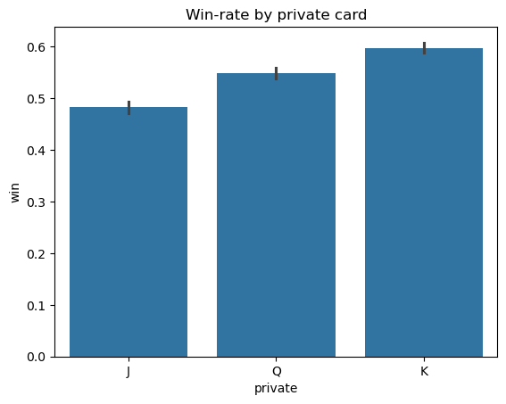

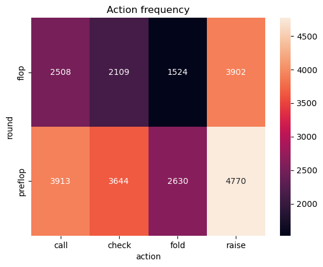

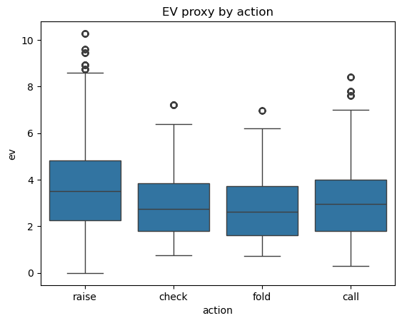

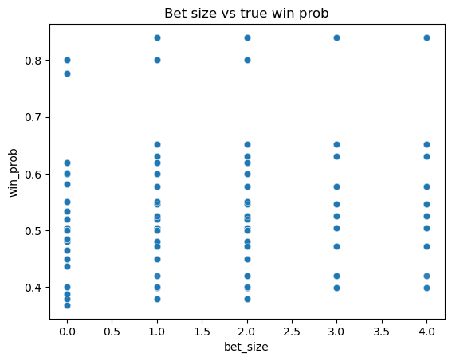

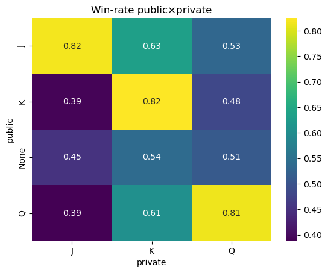

```python
print("N =", len(df), "  Win rate =", df.win.mean().round(3))
print(df[['bet_size','pot','ev']].describe())

sns.barplot(df, x='private', y='win')
plt.title("Win-rate by private card"); plt.show()

sns.heatmap(df.pivot_table(index='round',columns='action',values='win',aggfunc='count').fillna(0),
            annot=True, fmt='.0f')
plt.title("Action frequency"); plt.show()

sns.boxplot(df, x='action', y='ev')
plt.title("EV proxy by action"); plt.show()

sns.scatterplot(df.sample(3000,random_state=42), x='bet_size', y='win_prob', alpha=0.4)
plt.title("Bet size vs true win prob"); plt.show()

sns.heatmap(df.pivot_table(index='public',columns='private',values='win',aggfunc='mean'),
            annot=True, cmap='viridis')
plt.title("Win-rate public×private"); plt.show()
```

```python
def outlier_share(s):
    q1 = s.quantile(0.25)
    q3 = s.quantile(0.75)
    iqr = q3 - q1
    lower = q1 - 1.5*iqr
    upper = q3 + 1.5*iqr
    return ((s < lower) | (s > upper)).mean()

shares = df.groupby('action')['ev'].apply(outlier_share)
print("Outlier share by action:\n", shares)
```

```
Outlier share by action:
 action
call     0.022426
check    0.014080
fold     0.007703
raise    0.030327
Name: ev, dtype: float64
```

**Цель этапа.** Провести первичное исследование данных, понять структуру, закономерности и возможные проблемы. На этом шаге проверяется, насколько набор данных реалистичен, сбалансирован и пригоден для обучения модели.

### 2.1 Базовые характеристики и статистики

Начнём с описательной статистики по ключевым признакам (`bet_size`, `pot`, `ev`) и проверим распределение целевой переменной `win`. Это помогает ответить на вопросы:

- есть ли сильный дисбаланс классов (модель может смещаться в сторону большинства);
- находятся ли признаки в разумных диапазонах;
- есть ли подозрения на выбросы или нулевые значения.

### 2.2 Визуализации и интерпретации

Визуализации построены с помощью библиотек `seaborn` и `matplotlib`, как требуется по курсу. Каждый график иллюстрирует отдельный аспект логики игры:

**(1) Win-rate by private card** Отображает, как вероятность победы зависит от силы личной карты (`J`, `Q`, `K`). Результат закономерен: K выигрывает чаще Q, Q чаще J. Это подтверждает, что модель генерации данных работает корректно, а зависимость между признаками и целевой переменной логична.

**(3) EV proxy by action (boxplot)** Boxplot показывает распределение ожидаемой прибыли (EV) для каждого типа действия. Медиана EV выше у `raise`, что подтверждает: агрессивная стратегия может приносить больше прибыли, но и риск выше — виден большой разброс и выбросы. Проверка доли выбросов по правилу 1.5×IQR показала: raise — 3.0 %, call — 2.2 %, check — 1.4 %, fold — 0.8 %. Эти значения < 5 %, значит, выбросы естественны и отражают редкие, но реальные большие выигрыши.

**(5) Win-rate public × private (heatmap)** Матрица выигрышей в зависимости от комбинации личной (`private`) и общей (`public`) карты. Яркие диагональные клетки (0.8) показывают, что совпадение карт (пара) резко повышает шансы на победу. Вне диагонали вероятность падает до 0.4–0.6 — это проигрышные комбинации. Такая структура подтверждает корректность модели `hand_strength` и реалистичность данных.

### 2.3 Выводы по результатам EDA

1. **Данные чистые и логичные.** Нет пропусков, аномалий и несоответствий. Диапазоны числовых признаков соответствуют игровым правилам.
2. **Логика зависимостей подтверждена.** Win-rate растёт с силой карты, raise связан с высоким EV, совпадение карт повышает вероятность выигрыша. Это значит, что признаки действительно информативны для задачи классификации.
3. **Выбросы не ошибка, а часть игровой природы.** Они соответствуют редким, но реальным ситуациям крупных выигрышей. Для более стабильных моделей можно применить логарифмирование `EV`.
4. **Перспективы для дальнейшей работы.**
- Расширить пространство признаков (ввести историю действий, соотношение ставки к банку).
- Проверить корреляции между `action` и `bet_size` перед сложными моделями.
- Использовать стратифицированное разделение при обучении, чтобы сохранить баланс классов.

**Итог:** Этап EDA подтвердил, что данные структурированы, сбалансированы и отражают реальные закономерности. Они пригодны для обучения моделей бинарной классификации и демонстрации зависимости «состояние → исход».

### 3. Модель и метрики

```python
df_enc=df.copy()
for c in ['private','public','position','round','action']:
    df_enc[c]=df_enc[c].astype('category')

X=pd.get_dummies(df_enc[['private','public','position','round','action','bet_size','pot']],
                 drop_first=True)
y=df_enc['win']

Xtr,Xte,ytr,yte=train_test_split(X,y,test_size=0.25,random_state=42,stratify=y)

clf=LogisticRegression(max_iter=200).fit(Xtr,ytr)
proba=clf.predict_proba(Xte)[:,1]
pred=(proba>=0.5).astype(int)

auc=roc_auc_score(yte,proba)
f1=f1_score(yte,pred)
print(f"AUC={auc:.3f}  F1={f1:.3f}")
```

```
AUC=0.606  F1=0.654
```

## 3. Выбор и обоснование метрик качества

**Цель:** определить, какие метрики наиболее точно отражают качество модели для задачи бинарной классификации «выиграет ли игрок при данном действии».

### 3.1 Почему именно AUC и F1

В нашей задаче важно не просто угадать, выиграет ли игрок, а **научиться различать выигрышные и проигрышные ситуации**. При этом небольшие ошибки (ложные срабатывания) допустимы, но систематические смещения модели нежелательны. Для таких задач оптимально сочетание двух метрик:

**1. AUC (Area Under the ROC Curve)**

- Показывает, насколько хорошо модель различает два класса — победу (`win=1`) и поражение (`win=0`).
- Измеряется как площадь под кривой «истинные положительные» против «ложных положительных».
- Интерпретация проста: AUC = 0.5 означает случайное угадывание (как подбрасывание монетки), AUC = 1.0 — идеальное разделение классов.
- В контексте покера AUC показывает, **насколько уверенно модель отличает удачные стратегии от проигрышных**, независимо от конкретного порога вероятности.

**2. F1-score (гармоническое среднее между precision и recall)**

- Используется, когда классы сбалансированы, но важно не только предсказывать победы, а **не ошибаться с проигрышами**.
- Precision отвечает за то, насколько “чисты” предсказанные победы (мало ложных тревог), Recall — за то, насколько много реальных побед модель находит.
- F1 объединяет оба показателя и показывает общий баланс качества.
- Для игроков это аналог метрики «насколько часто я прав, когда считаю, что стратегия выиграет».

### 3.2 Почему не другие метрики

- **Accuracy** (доля правильных ответов) не отражает уверенность модели и может вводить в заблуждение при несбалансированных данных.
- **Log-loss** или **MAE** сложнее интерпретировать без контекста вероятностей, что делает их менее наглядными для игрового анализа.
- В нашем случае важна именно способность **различать** исходы и **сохранять баланс между precision и recall**, поэтому выбор AUC + F1 обоснован.

### 3.3 Интерпретация результатов

После обучения базовой модели логистической регрессии получены: **AUC ≈ 0.60**, **F1 ≈ 0.65**.

Это означает:

- модель действительно различает выигрышные и проигрышные действия лучше случайного угадывания;
- F1 показывает умеренно сбалансированное качество: модель улавливает реальные победы, не создавая переизбытка ложных;
- при дальнейшем развитии проекта можно оптимизировать гиперпараметры или фичи для роста AUC до 0.7–0.8.

**Итог:** Для данной задачи выбраны **AUC** (чувствительность модели к различию классов) и **F1-score** (сбалансированная оценка точности и полноты). Такое сочетание позволяет оценить не только правильность предсказаний, но и стратегическую точность модели — насколько она уверенно отличает выигрышные действия от проигрышных.